# From mutations to Proteins: Omics Data Analysis Report

Mariangela Santorsola

03/01/2024

# Result summary

# RNAseq data analysis

## Experimental design

This section contains the results of a RNAseq dataset, including one control sample and one treatment sample, each in three biological replicates.

| Group | Sample |
| --- | --- |
| control | sample_01 |
| control | sample_02 |
| control | sample_03 |
| case | sample_04 |
| case | sample_05 |
| case | sample_06 |

## Data Processing

### Read alignment and Quantification

- The reads from FASTQ files were processed by **Salmon**, *a pseudo-alignment* tool included in the **nf-core/rnaseq** pipeline, using the Human Reference Genome GRCh38.
- The nf-core/rnaseq pipeline was lauched by the following command line:

```bash
nextflow run nf-core/rnaseq -r 3.12.0 \
--input  datasets_lesson33/rnaseq/reads/rnaseq_samplesheet.csv \
--outdir results-in-you-bucket \
--genome GRCh38chr21 \
--pseudo_aligner salmon \
--skip_alignment \
--skip_biotype_qc \
-c rnaseq_nextflow.config \
-profile gls \
--skip_stringtie \
--skip_bigwig \
--skip_umi_extract \
--skip_trimming \
--skip_fastqc
```

- The config file used to launch nf-core/rnaseq is available at rnaseq_nextflow.config

## Differential Expression Analysis

- **DESeq2** R package was used to perform the Differential Expression (DE) analysis, and find the list of de-regulated genes when comparing **treaments vs controls**.
- The *gene-level* quantifications from nf-core/rnaseq were directly used to perform the DE analysis by DESeq2:

```r
load(params$dds)

#define conditions, e.g. treatment and control
colData(dds)$Group1 <- as.factor(colData(dds)$Group1)

#define the design of comparison, treatments vs controls
design(dds) <- as.formula("~Group1")

#get Differentially Expressed genes
dds <- DESeq(dds)
```

### Summary

```
##
## out of 229 with nonzero total read count
## adjusted p-value < 0.1
## LFC > 0 (up)       : 3, 1.3%
## LFC < 0 (down)     : 2, 0.87%
## outliers [1]       : 0, 0%
## low counts [2]     : 0, 0%
## (mean count < 47)
## [1] see 'cooksCutoff' argument of ?results
## [2] see 'independentFiltering' argument of ?results
```

### MA plot

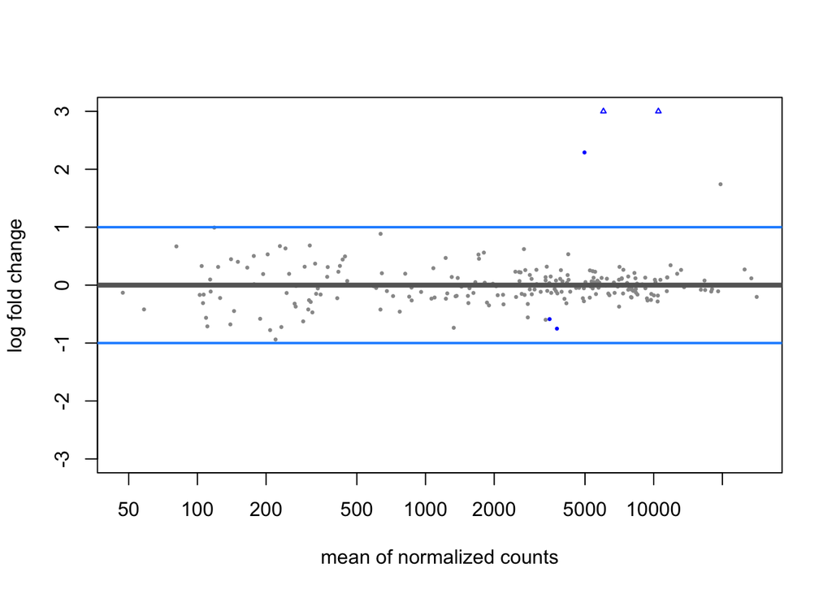

Plot showing the log2 fold change over the mean of normalized counts for analysed samples

### Dispersion plot

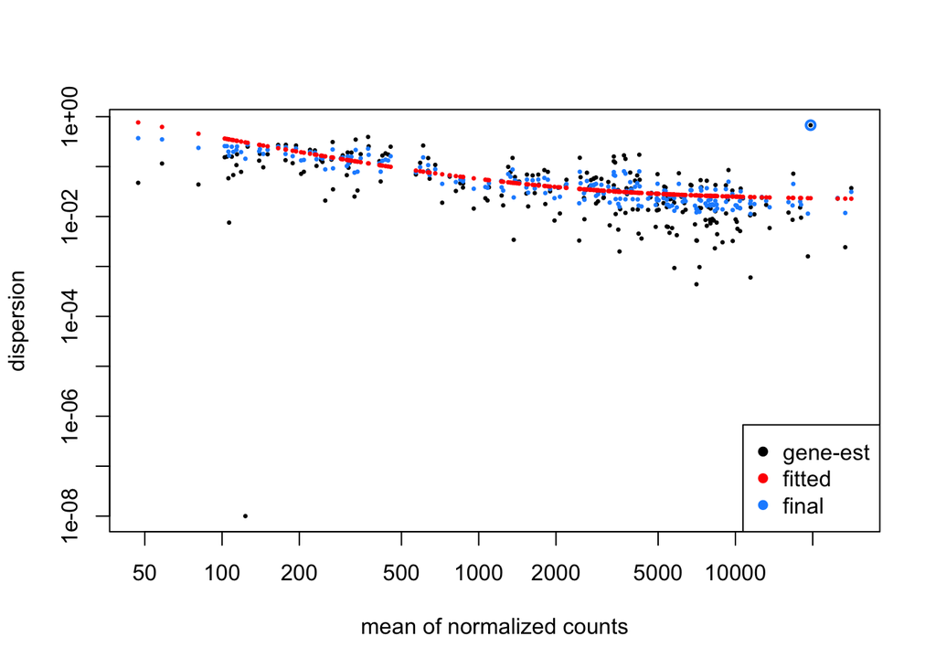

Dispersion plot showing the final estimates shrunking from gene-wise estimates towards fitted estimates.

### List of Differentially Expressed Genes

| Gene | log2FoldChange | pvalue | padj |
| --- | --- | --- | --- |
| ENSG00000183527 | 3.3562740 | 0.0000000 | 0.0000000 |
| ENSG00000154719 | 3.4293710 | 0.0000000 | 0.0000000 |
| ENSG00000142168 | 2.2898330 | 0.0000000 | 0.0000000 |
| ENSG00000157557 | -0.5869632 | 0.0002206 | 0.0126273 |
| ENSG00000160208 | -0.7512354 | 0.0004250 | 0.0194639 |

Table listing the statistically significan DE genes. For each gene, the log2 fold-change, p-value and adjusted pvalue are shown.

# Re-sequencing data analysis

## Experimental design

The re-sequencing dataset includes one control sample and one case sample.

| Group | Sample |
| --- | --- |
| control | normal_1.000+disease_0.000 |
| case | normal_0.000+disease_1.000 |

## Data Processing

### Variant calling and annotation

```bash
nextflow run nf-core/sarek -r 3.3.2 \
--input datasets_lesson33/germline/reads/sarek_samplesheet.csv \
--outdir results-in-you-bucket \
--igenomes_ignore true \
--genome GRCh38chr21 \
--tools haplotypecaller,snpeff \
--skip_tools haplotypecaller_filter \
--joint_germline \
--intervals datasets_lesson33/germline/chr21_intervals.list \
-c sarek_nextflow.config \
-profile gls
```

- The config file used to run nf-core/sarek is available at sarek_nextflow.config

Read vcf file from nf-core/sarek:

```r
vcf <- readVcf(params$vcf)
```

Create the table of annotations by the INFO field within the VCF file:

```r
variants <- rowRanges(vcf)
variants$`REF` <- as.character(variants$`REF`)
variants$`ALT` <- as.character(variants$`ALT`[[1]][[1]])
variants <- as_tibble(variants)
variants$variantName = names(rowRanges(vcf))
variants = cbind(variants, as_tibble(geno(vcf)$GT))
variants$gene <- unlist(lapply(info(vcf)$ANN, get_most_severe_gene))
variants$ens <- unlist(lapply(info(vcf)$ANN, get_most_severe_ens))
variants$transcript <- unlist(lapply(info(vcf)$ANN, get_most_severe_tr))
variants$aa_change <- unlist(lapply(info(vcf)$ANN, get_most_severe_aa_change))
variants$consequence <- unlist(lapply(info(vcf)$ANN, get_most_severe_consequence))
variants$impact <- unlist(lapply(info(vcf)$ANN, get_most_severe_impact))
```

### Localization and biological consequences of identified mutations

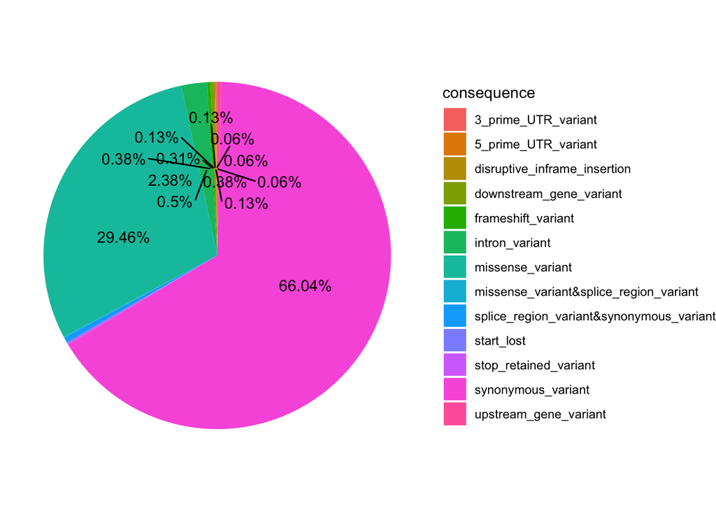

Distribution of the percentage of identified mutations across biological consequence categories

| consequence | count |
| --- | --- |
| synonymous_variant | 1056 |
| missense_variant | 471 |
| intron_variant | 38 |
| splice_region_variant&synonymous_variant | 8 |
| downstream_gene_variant | 6 |
| upstream_gene_variant | 6 |
| frameshift_variant | 5 |
| 3_prime_UTR_variant | 2 |
| start_lost | 2 |
| stop_retained_variant | 2 |
| 5_prime_UTR_variant | 1 |
| disruptive_inframe_insertion | 1 |
| missense_variant&splice_region_variant | 1 |

Total number of identified mutations across biological consequence categories within analysed samples.

## Variant Filtering

### Filtering Criteria

To filter the most clinically relevant mutations, the following process was followed:

1. Select **mutations occurring in cases** and not present in matched controls
2. Select the mutations with **HIGH** or **MODERATE** impact from SnpEff annotation
3. Select the **mutations occurring in Differentially Expressed Genes**
4. Select **missense** mutations
5. Select mutations with **high Alphamissense pathogenicity score**

```r
filteredVars = variants %>%
  filter(control_control1 == "0/0" &
            (impact == "MODERATE" | impact == "HIGH") &
            ens %in% significant_de_genes &
            consequence == "missense_variant")
filteredVars <- as_tibble(filteredVars)
```

### Filtered mutations for further validation assays

| seqnames | start | REF | ALT | gene | consequence | aa_change |
| --- | --- | --- | --- | --- | --- | --- |
| chr21 | 31659828 | A | G | SOD1 | missense_variant | p.Asn20Ser |
| chr21 | 31667290 | A | G | SOD1 | missense_variant | p.Asp91Ala |
| chr21 | 31667364 | C | G | SOD1 | missense_variant | p.Arg116Gly |
| chr21 | 38814278 | G | G | ETS2 | missense_variant | p.Ala64Thr |
| chr21 | 38818484 | C | G | ETS2 | missense_variant | p.Leu217Ile |
| chr21 | 39175629 | C | G | PSMG1 | missense_variant | p.Leu276Phe |

### Alphamissense Pathogenicity Predictions of filtered variants

| seqnames | start | REF | ALT | gene | consequence | aa_change | alphamis_Pathogenicity | alphamis_Class |
| --- | --- | --- | --- | --- | --- | --- | --- | --- |
| chr21 | 31659828 | A | G | SOD1 | missense_variant | p.Asn20Ser | 0.085 | likely_benign |
| chr21 | 31667290 | A | G | SOD1 | missense_variant | p.Asp91Ala | 0.149 | likely_benign |
| chr21 | 31667364 | C | G | SOD1 | missense_variant | p.Arg116Gly | 0.977 | likely_pathogenic |
| chr21 | 38814278 | G | G | ETS2 | missense_variant | p.Ala64Thr | 0.062 | likely_benign |
| chr21 | 38818484 | C | G | ETS2 | missense_variant | p.Leu217Ile | 0.076 | likely_benign |
| chr21 | 39175629 | C | G | PSMG1 | missense_variant | p.Leu276Phe | 0.106 | likely_benign |

### Gene constraint metrics from gnomAD

| Gene | LOEUF |
| --- | --- |
| SOD1 | 1.515 |
| ETS2 | 0.434 |
| PSMG1 | 0.927 |

## Results: Prioritized variant(s)

| seqnames | start | REF | ALT | gene | consequence | aa_change | alphamis_Pathogenicity | alphamis_Class | Clinical_significance | gnomAD_AF |
| --- | --- | --- | --- | --- | --- | --- | --- | --- | --- | --- |
| chr21 | 31667364 | C | G | SOD1 | missense_variant | p.Arg116Gly | 0.977 | likely_pathogenic | Pathogenic/Likely pathogenic | variant not found |

**Clinical_significance* annotations are from the ClinVar database.